# Module 5 - Model Specification

## The Oil Price Series

We applied the difference of natural log transformation to the monthly oil price time series to make it stationary. The software implementation of the Augmented Dickey-Fuller unit-root test applied to the logs of the original prices with $k=6$ leads to a test statistic of −1.1119 and a p-value of 0.9189. With stationarity as the alternative hypothesis, this provides strong evidence of nonstationarity and the appropriateness of taking a difference of the logs.

We give EACF for the difference of logarithms for this series below. EACF table suggests ARIMA(0,1,1) model for the differences.

```r
eacf(diff(log(oil.price)))
```

```
## AR/MA
##   0 1 2 3 4 5 6 7 8 9 10 11 12 13
## 0 x o o o o o o o o o o  o  o  o
## 1 x x o o o o o o o o x  o  o  o
## 2 o x o o o o o o o o o  o  o  o
## 3 o x o o o o o o o o o  o  o  o
## 4 o x x o o o o o o o o  o  o  o
## 5 o x o x o o o o o o o  o  o  o
## 6 o x o x o o o o o o o  o  o  o
## 7 x x o x o o o o o o o  o  o  o
```

The results of the best subsets ARMA approach are given below.

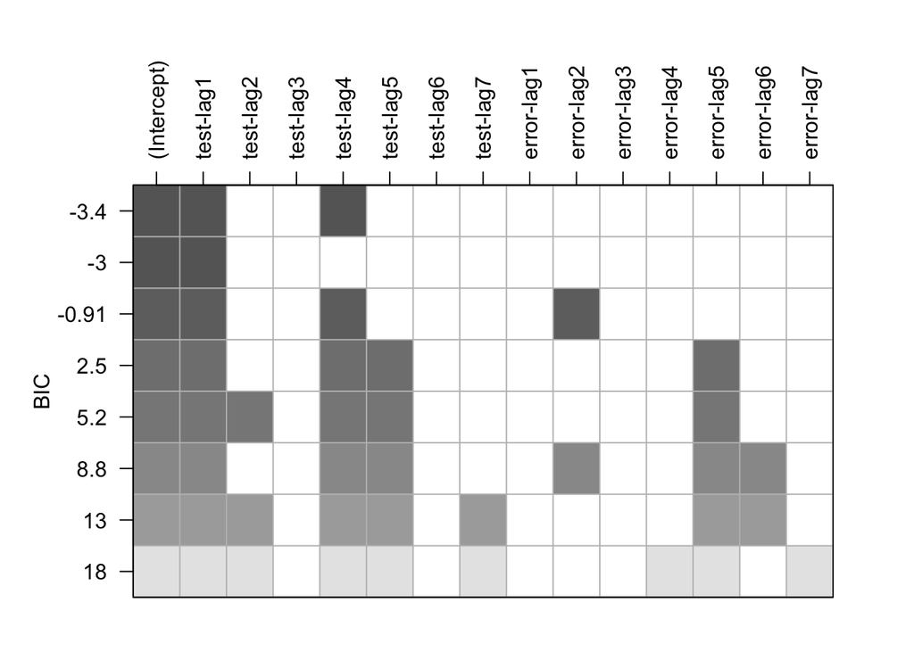

```r
res=armasubsets(y=diff(log(oil.price)),nar=7,nma=7,y.name='test', ar.method='ols')
plot(res)
```

Because we get the smallest BIC at lags 1 and 4, $Y_{t} = \nabla \log(Oil_{t})$ should be modeled in terms of $Y_{t-1}$ and $Y_{t-4}$ and that no lags are needed in the error terms. The second best model omits the lag 4 terms so that an ARIMA(1,1,0) model on the logarithms should also be investigated further.

The sample ACF and PACF plots for the oil price series are given in the following plots.

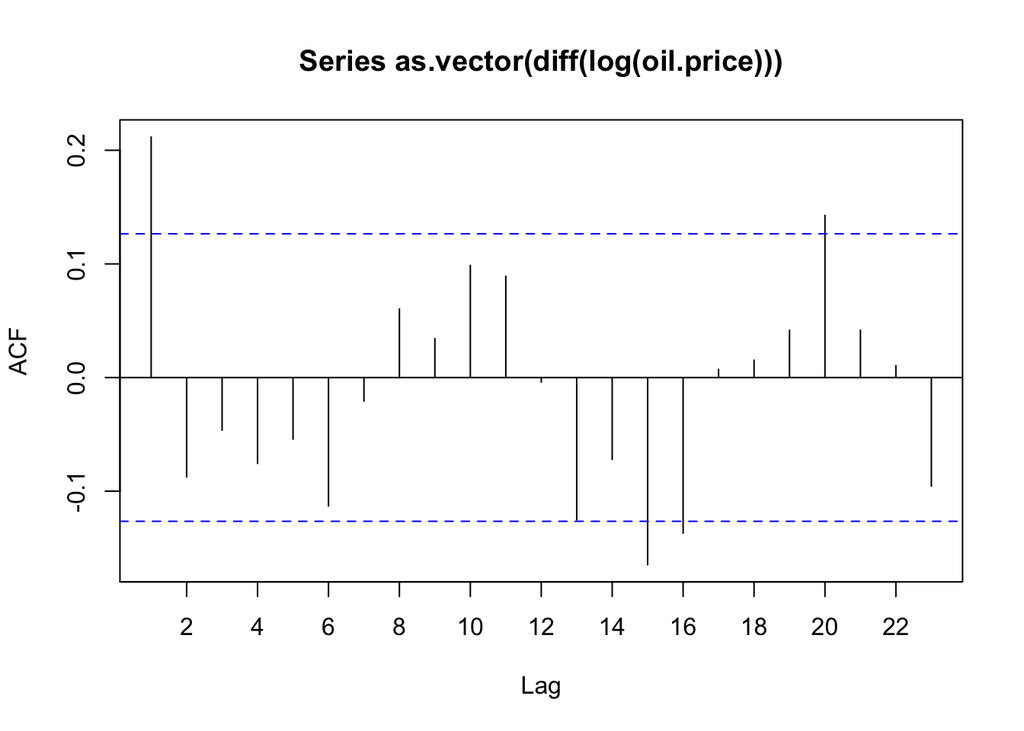

```r
acf(as.vector(diff(log(oil.price))),xaxp=c(0,22,11))
```

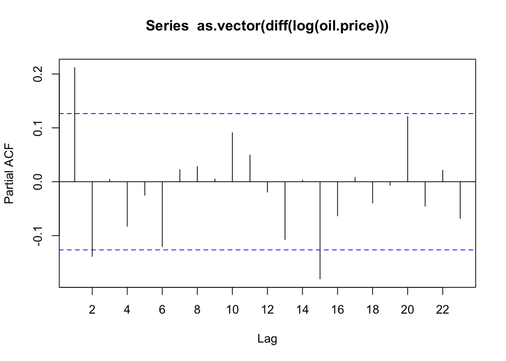

```r
pacf(as.vector(diff(log(oil.price))),xaxp=c(0,22,11))
```

Because we have one significant pike at the first lag in ACF and two significant pikes at the first two lags in PACF, we can consider MA(1) or AR(2) models on the difference of log of series.

# Summary

In this module, we considered the problem of specifying reasonable but simple models for observed times series. In particular,

- we investigated the sample autocorrelation function, the sample partial autocorrelation function, and the sample extended autocorrelation function for choosing the orders (p, d, and q) for ARIMA(p,d,q) models.
- The Dickey-Fuller unit-root test was introduced to help distinguish between stationary and nonstationary series.
- Model selection criteria are used to identify the most promising model.
- These ideas were all illustrated with both simulated and actual time series.

# References

Wei. W.W.S. Time Series Analysis: Univariate and Multivariate Methods. Wiley, New York, 2006.